# 盈利模式

分析购彩助手数据 (第II部)

特邀导师 - 菜菜

2022-06-10

# 1 设定

## 1.1 SCSS 设置

```r
# install.packages('remotes', dependencies = TRUE, INSTALL_opts = '--no-lock')
library('BBmisc', 'rmsfuns')
#remotes::install_github("rstudio/sass")
lib('sass')

## https://support.rstudio.com/hc/en-us/articles/200532197
## https://community.rstudio.com/t/r-does-not-display-korean-chinese/30889/3?u=englianhu
#Sys.setlocale("LC_CTYPE", "en_US.UTF-8")
#Sys.setlocale("LC_CTYPE", "zh_CN.UTF-8")
#Sys.setlocale(category = "LC_CTYPE", "Chinese (Simplified)_China.936")
#Sys.setlocale(locale = "Chinese")
#Sys.setlocale(locale = "Japanese")
#Sys.setlocale(locale = "English")

# rmarkdown::render('/home/englianhu/Documents/owner/ryo-cn.Rmd',  encoding = 'UTF-8')
#Sys.setlocale("LC_CTYPE", "UTF-8")
#Sys.setlocale(locale = "UTF-8")
#Sys.setlocale(category = "LC_ALL", locale = "chs")
#Sys.setlocale(category = "LC_ALL", locale = "UTF-8")
#Sys.setlocale(category = "LC_ALL", locale = "Chinese")
#Sys.setlocale(category = "LC_ALL", locale = "zh_CN.UTF-8")
Sys.setlocale("LC_ALL", "en_US.UTF-8")
```

```
/* https://stackoverflow.com/a/66029010/3806250 */
h1 { color: #002C54; }
h2 { color: #2F496E; }
h3 { color: #375E97; }
h4 { color: #556DAC; }
h5 { color: #92AAC7; }

/* ----------------------------------------------------------------- */
/* https://gist.github.com/himynameisdave/c7a7ed14500d29e58149#file-broken-gradient-animation-less */
.hover01 {
  /* color: #FFD64D; */
  background: linear-gradient(155deg, #EDAE01 0%, #FFEB94 100%);
  transition: all 0.45s;
  &:hover{
    background: linear-gradient(155deg, #EDAE01 20%, #FFEB94 80%);
    }
  }

.hover02 {
  color: #FFD64D;
  background: linear-gradient(155deg, #002C54 0%, #4CB5F5 100%);
  transition: all 0.45s;
  &:hover{
    background: linear-gradient(155deg, #002C54 20%, #4CB5F5 80%);
    }
  }

.hover03 {
  color: #FFD64D;
  background: linear-gradient(155deg, #A10115 0%, #FF3C5C 100%);
  transition: all 0.45s;
  &:hover{
    background: linear-gradient(155deg, #A10115 20%, #FF3C5C 80%);
    }
  }
```

```r
## Set the timezone but not change the datetime
Sys.setenv(TZ = 'Asia/Shanghai')

## Setting to omit all warnings
## https://stackoverflow.com/a/36846793/3806250
## Set width
## options(knitr.table.format = 'html') will set all kableExtra tables to be 'html', otherwise need to set the parameter on every single table.
options(warn = -1, width = 999, knitr.table.format = 'html')#, digits.secs = 6)

## https://stackoverflow.com/questions/39417003/long-vectors-not-supported-yet-abnor-in-rmd-but-not-in-r-script
## https://yihui.org/knitr/options
knitr::opts_chunk$set(
  class.source = 'hover01', class.output = 'hover02', class.error = 'hover03',
  message = FALSE, warning = FALSE, error = TRUE,
  autodep = TRUE, aniopts = 'loop',
  progress = TRUE, verbose = TRUE,
  cache = FALSE, cache.lazy = FALSE, result = 'asis')
```

## 1.2 设置

```r
## Setup Options, Loading Required Libraries and Preparing Environment
## Loading the packages and setting adjustment
source('function/libs.R')
```

读取程序包

```r
## Setup Options, Loading Required Libraries and Preparing Environment
## 3210448065@qq.com
## leiou123

## 2849108450@qq.com
## leiou123
## https://rstudio.cloud/project/1198888

## Loading the package 'BBmisc'
if(suppressMessages(!require('BBmisc'))){
  install.packages('BBmisc', dependencies = TRUE, INSTALL_opts = '--no-lock')
  suppressMessages(library('BBmisc'))
}
if (suppressMessages(!require('rmsfuns'))) {
  install.packages('rmsfuns', dependencies = TRUE, INSTALL_opts = '--no-lock')
  suppressMessages(library('rmsfuns'))
}

if(!require('REmap')) devtools::install_github('lchiffon/REmap')

## Loading multiple packages at once
#pkgs <- c('readr', 'plyr', 'dplyr', 'magrittr', 'tidyverse', 'devtools', 'zoo', 'lubridate', 'stringr', 'rvest', 'markdown', 'googleVis', 'knitr', 'rmarkdown', 'htmltools', 'knitr', 'kableExtra', 'formattable', 'echarts4r', 'radarchart', 'MASS', 'htmlwidgets', 'maps', 'REmap', 'ggmap', 'vembedr')

pkgs <- c('plyr', 'dplyr', 'magrittr', 'stringr', 'knitr', 'kableExtra', 'lubridate', 'broom', 'purrr', 'readxl', 'tibble', 'DT')

suppressAll(lib(pkgs))
load_pkg(pkgs)
rm(pkgs)

## Set the googleVis options first to change the behaviour of plot.gvis, so that
##  only the chart component of the HTML file is written into the output file.
op <- options(gvis.plot.tag = 'chart')

## <audio src='music/bigmoney.mp3' autoplay controls loop></audio>
```

```r
conflict_prefer('filter', 'dplyr')
conflict_prefer('select', 'dplyr')
conflict_prefer('mutate', 'dplyr')
conflict_prefer('rename', 'dplyr')
```

# 2 简介

[盈利模式 - 分析购彩助手数据](https://rpubs.com/englianhu/goucai)使用广义型线性模型`glm`推算出`大`与`单`的出现率较高，*盈利模式 - 分析购彩助手数据*

# 3 数据

## 3.1 样本数据

账号：`zxg00123`，以下是从我们平台购彩助手中的官方数据采集下来的数据，什么彩种都可以分析，就拿个主打**1分快3**为样本。

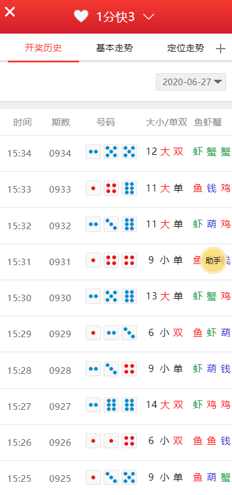

```r
hml <- read.delim(file = '1分快3样本数据2.txt')
hml %<>%
  unlist %>%
  as.character

#时间 期数 号码 大小/单双 鱼虾蟹
#12:41 0761 dice1 dice1 dice57 小 单 鱼 鱼 蟹
smp <- c('12:41', '0761', 'dice1 dice1 dice5', '7 小 单', '鱼 鱼 蟹') %>%
  matrix(ncol = 1, byrow = TRUE) %>%
  t %>%
  data.frame
nm <- c('时间', '期数', '号码', '大小/单双', '鱼虾蟹')
names(smp) <- nm
smp %<>%
  as_tibble

smp %>%
  kable(caption = '1分快3样本数据') %>%
  kable_styling(
    bootstrap_options = c('striped', 'hover', 'condensed', 'responsive')) %>%
  row_spec(0, bold = TRUE, color = '#FDD017', background = '#3A3B3C') %>%
  row_spec(1, color = '#FFFF00', background = '#657383')
```

## 3.2 整理数据

```r
smpp <- hml %>%
  llply(., function(x) {
    x %>%
      str_extract_all('([0-9]{2}:[0-9]{2})|([0-9]{1,2}%)|(\\w+)') %>%
      unlist %>%
      str_replace_all('2e1d3b04', '') %>%
      str_replace_all('([0-9]+[a-zA-Z]+)|([a-zA-Z]+)|[0-9]{1,2}%', '') %>%
      .[nchar(.)>0] %>%
      t %>%
      data.frame
    }) %>%
  bind_rows %>%
  as_tibble

names(smpp) <- c('时间', '期数', '骰子1', '骰子2', '骰子3', '总值', '大小', '单双', '鱼虾蟹1', '鱼虾蟹2', '鱼虾蟹3')

smpp %<>% mutate(
  `时间` = hm(`时间`), `期数` = factor(`期数`),
  `骰子1` = as.numeric(`骰子1`), `骰子2` = as.numeric(`骰子2`),
  `骰子3` = as.numeric(`骰子3`), `总值` = as.numeric(`总值`),
  `大小` = factor(`大小`), `单双` = factor(`单双`),
  `鱼虾蟹1` = factor(`鱼虾蟹1`), `鱼虾蟹2` = factor(`鱼虾蟹2`),
  `鱼虾蟹3` = factor(`鱼虾蟹3`))

smppp <- smpp[c('总值', '大小', '单双')]

smpp %>%
  datatable(
    caption = "1分快3样本数据",
    escape = FALSE, filter = 'top', rownames = FALSE,
    extensions = list(
      'ColReorder' = NULL, 'RowReorder' = NULL,
      'Buttons' = NULL, 'Responsive' = NULL),
    options = list(
      dom = 'BRrltpi', autoWidth = TRUE,  scrollX = TRUE,
      lengthMenu = list(c(10, 50, 100, -1), c('10', '50', '100', 'All')),
      ColReorder = TRUE, rowReorder = TRUE,
      buttons = list('copy', 'print',
                     list(extend = 'collection',
                          buttons = c('csv', 'excel', 'pdf'),
                          text = 'Download'), I('colvis'))))
```

# 4 统计模型

## 4.1 基本分析

```r
smpp[-c(1:2)] %>%
  llply(table)
```

```r
yy <- suppressMessages(
  llply(3:18, function(i) {
    dpois(i, smppp$总值) %>%
      round(2)
    }) %>%
    bind_cols)

names(yy) <- paste0('X', 3:18)
yy <- data.frame(smppp, yy) %>%
  as_tibble

yy %>%
  kable(caption = '和值概率明细') %>%
  kable_styling(
    bootstrap_options = c('striped', 'hover', 'condensed', 'responsive')) %>%
  row_spec(0, bold = TRUE, color = '#FDD017', background = '#3A3B3C') %>%
  row_spec(seq(1, nrow(yy), by = 2), color = '#FFFF00', background = '#657383') %>%
  row_spec(seq(2, nrow(yy), by = 2), color = '#FFFF00', background = '#C0C0C0') %>%
  scroll_box(width = '100%', height = '400px')
```

```r
table(smpp$`总值`)
prop.table(table(smpp$`总值`))
barplot(prop.table(table(smpp$`总值`)))
```

```r
table(smpp$`大小`)
prop.table(table(smpp$`大小`))
barplot(prop.table(table(smpp$`大小`)))
```

```r
table(smpp$`单双`)
prop.table(table(smpp$`单双`))
barplot(prop.table(table(smpp$`单双`)))
```

```r
table(smpp$`鱼虾蟹1`)
prop.table(table(smpp$`鱼虾蟹1`))
barplot(prop.table(table(smpp$`鱼虾蟹1`)))
```

```r
table(smpp$`鱼虾蟹2`)
prop.table(table(smpp$`鱼虾蟹2`))
barplot(prop.table(table(smpp$`鱼虾蟹2`)))
```

```r
table(smpp$`鱼虾蟹3`)
prop.table(table(smpp$`鱼虾蟹3`))
barplot(prop.table(table(smpp$`鱼虾蟹3`)))
```

## 4.2 统计建模

以下是以广义型泊松模型预测开奖率。

```r
### 计算总值概率

## https://stats.stackexchange.com/questions/272194/interpreting-poisson-output-in-r
md1a <- glm(`总值`~`骰子1`+`骰子2`+`骰子3`, data = smpp, family = poisson)

md1b <- glm(`总值`~`骰子1`+`骰子2`+`骰子3` - 1, data = smpp, family = poisson)

ldply(
  list(md1a, md1b), AIC) %>%
  data.frame(`模型` = c('截距', '没截距'), .) %>%
  dplyr::rename(AIC = V1) %>%
  dplyr::mutate(Rank = rank(AIC)) %>%
  kable(caption = '统计模型') %>%
  kable_styling(
    bootstrap_options = c('striped', 'hover', 'condensed', 'responsive')) %>%
  row_spec(0, bold = TRUE, color = '#FDD017', background = '#3A3B3C') %>%
  row_spec(1, color = '#FFFF00', background = '#657383') %>%
  row_spec(2, color = '#FFFF00', background = '#6D7B8D')
```

```r
md1a.pp <- md1a %>%
  coef %>%
  exp %>%
  llply(., function(x) {dpois(3:18, x)}) %>%
  bind_cols %>%
  data.frame(x = 3:18, .)

names(md1a.pp) <- c('x', '截距', '骰子1', '骰子2', '骰子3')
md1a.pp %>%
  kable(caption = '统计模型') %>%
  kable_styling(
    bootstrap_options = c('striped', 'hover', 'condensed', 'responsive')) %>%
  row_spec(0, bold = TRUE, color = '#FDD017', background = '#3A3B3C') %>%
  row_spec(seq(1, nrow(md1a.pp), by = 2), color = '#FFFF00', background = '#657383') %>%
  row_spec(seq(2, nrow(md1a.pp), by = 2), color = '#FFFF00', background = '#C0C0C0') %>%
  scroll_box(width = '100%', height = '400px')
```

### 4.2.1 计算大小概率

```r
md2a <- glm(as.numeric(`大小`)~`骰子1`+`骰子2`+`骰子3`, data = smpp, family = poisson)

md2b <- glm(as.numeric(`大小`)~`骰子1`+`骰子2`+`骰子3` - 1, data = smpp, family = poisson)

ldply(list(md2a, md2b), AIC) %>%
  data.frame(`模型` = c('截距', '没截距'), .) %>%
  dplyr::rename(AIC = V1) %>%
  dplyr::mutate(Rank = rank(AIC)) %>%
  kable(caption = '统计模型') %>%
  kable_styling(
    bootstrap_options = c('striped', 'hover', 'condensed', 'responsive')) %>%
  row_spec(0, bold = TRUE, color = '#FDD017', background = '#3A3B3C') %>%
  row_spec(1, color = '#FFFF00', background = '#657383') %>%
  row_spec(2, color = '#FFFF00', background = '#6D7B8D')
```

```r
md2a.pp <- md2a %>%
  coef %>%
  exp %>%
  llply(., function(x) {dpois(1:18, x)}) %>%
  bind_cols %>%
  data.frame(x = 1:18, .)

names(md1a.pp) <- c('x', '截距', '骰子1', '骰子2', '骰子3')
md1a.pp %>%
  kable(caption = '统计模型') %>%
  kable_styling(
  bootstrap_options = c('striped', 'hover', 'condensed', 'responsive')) %>%
  row_spec(0, bold = TRUE, color = '#FDD017', background = '#3A3B3C') %>%
  row_spec(seq(1, nrow(md1a.pp), by = 2), color = '#FFFF00', background = '#657383') %>%
  row_spec(seq(2, nrow(md1a.pp), by = 2), color = '#FFFF00', background = '#C0C0C0') %>%
  scroll_box(width = '100%', height = '400px')
```

### 4.2.2 计算单双概率

```r
md3a <- glm(as.numeric(`单双`)~`骰子1`+`骰子2`+`骰子3`, data = smpp, family = poisson)

md3b <- glm(as.numeric(`单双`)~`骰子1`+`骰子2`+`骰子3` - 1, data = smpp, family = poisson)

ldply(list(md3a, md3b), AIC) %>%
  data.frame(`模型` = c('截距', '没截距'), .) %>%
  dplyr::rename(AIC = V1) %>%
  dplyr::mutate(Rank = rank(AIC)) %>%
  kable(caption = '统计模型') %>%
  kable_styling(
    bootstrap_options = c('striped', 'hover', 'condensed', 'responsive')) %>%
  row_spec(0, bold = TRUE, color = '#FDD017', background = '#3A3B3C') %>%
  row_spec(1, color = '#FFFF00', background = '#657383') %>%
  row_spec(2, color = '#FFFF00', background = '#6D7B8D')
```

```r
md3a.pp <- md3a %>%
  coef %>%
  exp %>%
  llply(., function(x) {dpois(1:6, x)}) %>%
  bind_cols %>%
  data.frame(x = 1:6, .)

names(md1a.pp) <- c('x', '截距', '骰子1', '骰子2', '骰子3')

md1a.pp %>%
  kable(caption = '统计模型') %>%
  kable_styling(
  bootstrap_options = c('striped', 'hover', 'condensed', 'responsive')) %>%
  row_spec(0, bold = TRUE, color = '#FDD017', background = '#3A3B3C') %>%
  row_spec(seq(1, nrow(md1a.pp), by = 2), color = '#FFFF00', background = '#657383') %>%
  row_spec(seq(2, nrow(md1a.pp), by = 2), color = '#FFFF00', background = '#C0C0C0') %>%
  scroll_box(width = '100%', height = '400px')
```

```r
## load function files
pth <- paste0('function/bivpois/R/', list.files(path = 'function/bivpois/R/'))
l_ply(pth, source)

attr(smpp$单双,'contrasts') <- stats::contrasts(stats::C(factor(smpp$单双), sum))
attr(smpp$大小,'contrasts') <- stats::contrasts(stats::C(factor(smpp$大小), sum))
attr(smpp$单双,'levels') <- levels(factor(smpp$单双))
attr(smpp$大小,'levels') <- levels(factor(smpp$大小))

## formula for modeling of lambda1 and lambda2
#form1 <- ~c(team1,team2)+c(team2,team1)

## Model 1: Double Poisson
#ex4.m1<-lm.bp( g1~1, g2~1, l1l2=form1, zeroL3=TRUE, data=ex4.ita91)

## Models 2-5: bivariate Poisson models
#ex4.m2<-lm.bp(g1~1,g2~1, l1l2=form1, data=ex4.ita91, maxit=2)
#ex4.m3<-lm.bp(g1~1,g2~1, l1l2=form1, l3=~team1, data=ex4.ita91, maxit=2)
#ex4.m4<-lm.bp(g1~1,g2~1, l1l2=form1, l3=~team2, data=ex4.ita91, maxit=2)
#ex4.m5<-lm.bp(g1~1,g2~1, l1l2=form1, l3=~team1+team2, data=ex4.ita91, maxit=2)

form1 <- ~c('大小', '单双') + c('单双', '大小')
l1 = 总值~1; l2 = 总值~2; l1l2 = NULL; l3 = ~1; data = smppp; common.intercept = FALSE; zeroL3 = FALSE; maxit = 100; pres = 1e-8; verbose = getOption('verbose')

lm.bp(大小 ~ 1, 单双 ~ 2, l1l2 = form1, zeroL3 = TRUE, data = smpp)
lm.bp(大小 ~ 1, 单双 ~ 2, l1l2 = form1, data = smpp, maxit = 2)
lm.bp(大小 ~ 1, 单双 ~ 2, l1l2 = form1, l3 = ~单双, data = smpp, maxit = 2)
lm.bp(大小 ~ 1, 单双 ~ 2, l1l2 = form1, l3 = ~大小+单双, data = smpp, maxit = 2)
```